# All plots examples

Ewen Harrison

## 1 Odds ratio plots

### 1.01 Standard odds ratio plot (forest plot)

This is used to visually present the results from a multivariable generalised linear model (usually logistic regression).

Here is the model:

```r
library(finalfit)
explanatory = c("age.factor", "sex.factor", "obstruct.factor", "perfor.factor")
dependent = 'mort_5yr'
colon_s %>%
  finalfit(dependent, explanatory) %>%
    knitr::kable(row.names=FALSE) # This line only needed for formatting.
```

| Dependent: Mortality 5 year |  | Alive | Died | OR (univariable) | OR (multivariable) |
| --- | --- | --- | --- | --- | --- |
| Age | <40 years | 31 (46.3) | 36 (53.7) | - | - |
|  | 40-59 years | 208 (61.4) | 131 (38.6) | 0.54 (0.32-0.92, p=0.023) | 0.57 (0.34-0.98, p=0.041) |
|  | 60+ years | 272 (53.4) | 237 (46.6) | 0.75 (0.45-1.25, p=0.270) | 0.81 (0.48-1.36, p=0.426) |
| Sex | Female | 243 (55.6) | 194 (44.4) | - | - |
|  | Male | 268 (56.1) | 210 (43.9) | 0.98 (0.76-1.27, p=0.889) | 0.98 (0.75-1.28, p=0.902) |
| Obstruction | No | 408 (56.7) | 312 (43.3) | - | - |
|  | Yes | 89 (51.1) | 85 (48.9) | 1.25 (0.90-1.74, p=0.189) | 1.25 (0.90-1.76, p=0.186) |
| Perforation | No | 497 (56.0) | 391 (44.0) | - | - |
|  | Yes | 14 (51.9) | 13 (48.1) | 1.18 (0.54-2.55, p=0.672) | 1.12 (0.51-2.44, p=0.770) |

Simply switch to `or_plot()` for plot.

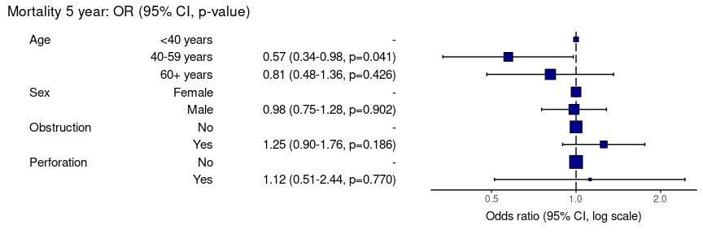

```r
library(finalfit)
explanatory = c("age.factor", "sex.factor", "obstruct.factor", "perfor.factor")
dependent = 'mort_5yr'
colon_s %>%
  or_plot(dependent, explanatory)
```

```r
# Note this example uses fig.height=3, fig.width=9
```

Adjust figure width and height to optimise formatting.

### 1.02 Mixed effects odds ratio plot (forest plot)

This is used to visually present the results from a mixed effects / multilevel / hierarchical generalised linear model (usually logistic regression).

Here is the model:

```r
library(finalfit)
explanatory = c("age.factor", "sex.factor", "obstruct.factor", "perfor.factor")
dependent = 'mort_5yr'
random_effect = "hospital"
colon_s %>%
  finalfit(dependent, explanatory, random_effect = random_effect)%>%
    knitr::kable(row.names=FALSE) # This line only needed for formatting.
```

| Dependent: Mortality 5 year |  | Alive | Died | OR (univariable) | OR (multilevel) |
| --- | --- | --- | --- | --- | --- |
| Age | <40 years | 31 (46.3) | 36 (53.7) | - | - |
|  | 40-59 years | 208 (61.4) | 131 (38.6) | 0.54 (0.32-0.92, p=0.023) | 0.75 (0.39-1.44, p=0.382) |
|  | 60+ years | 272 (53.4) | 237 (46.6) | 0.75 (0.45-1.25, p=0.270) | 1.03 (0.55-1.96, p=0.916) |
| Sex | Female | 243 (55.6) | 194 (44.4) | - | - |
|  | Male | 268 (56.1) | 210 (43.9) | 0.98 (0.76-1.27, p=0.889) | 0.80 (0.58-1.11, p=0.180) |
| Obstruction | No | 408 (56.7) | 312 (43.3) | - | - |
|  | Yes | 89 (51.1) | 85 (48.9) | 1.25 (0.90-1.74, p=0.189) | 1.23 (0.82-1.83, p=0.320) |
| Perforation | No | 497 (56.0) | 391 (44.0) | - | - |
|  | Yes | 14 (51.9) | 13 (48.1) | 1.18 (0.54-2.55, p=0.672) | 1.03 (0.43-2.51, p=0.940) |

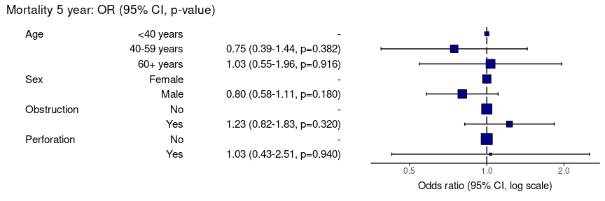

```r
library(finalfit)
explanatory = c("age.factor", "sex.factor", "obstruct.factor", "perfor.factor")
dependent = 'mort_5yr'
random_effect = "hospital"
colon_s %>%
  or_plot(dependent, explanatory, random_effect = random_effect)
```

```r
# Note this example uses fig.height=3, fig.width=9
```

### 1.03 Plotting a subset of variables from a full model

You may wish to only present a subset of variables from a full model, say an explanatory variable of interest without covariates to avoid table 2 fallacy.

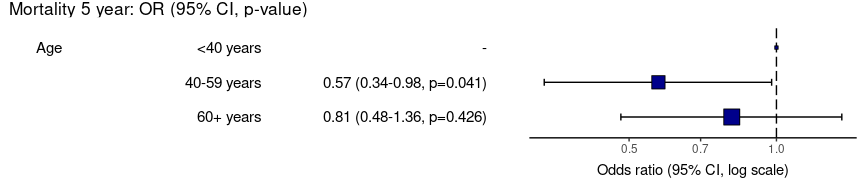

```r
library(finalfit)
explanatory = c("age.factor", "sex.factor", "obstruct.factor", "perfor.factor")
dependent = 'mort_5yr'

# Run summary_factorlist for variables you wish to include
## Include total_col = TRUE and fit_id = TRUE
factorlist  = colon_s %>%
    summary_factorlist(dependent, "age.factor", total_col = TRUE, fit_id = TRUE)

# Run full model including factorlist
colon_s %>%
  or_plot(dependent, explanatory, factorlist = factorlist)
```

```r
# Note this example uses fig.height=2, fig.width=9
```

### 1.04 Plotting from model object

When a model takes a long time to run, you do not want to re-run it to plot it. Pass the model object to the plotting function.

```r
library(finalfit)
explanatory = c("age.factor", "sex.factor", "obstruct.factor", "perfor.factor")
dependent = 'mort_5yr'
random_effect = "hospital"

fit = colon_s %>%
    glmmixed(dependent, explanatory, random_effect)

# Equivalent to:
fit = colon_s %>%
    lme4::glmer(mort_5yr ~ age.factor + sex.factor + obstruct.factor + perfor.factor + (1 | hospital),
                            family="binomial", data = .)

# Which is incidentally equivalent to:
fit = colon_s %>%
    lme4::glmer(ff_formula(dependent, explanatory, random_effect),
                            family="binomial", data = .)

# Plot
system.time(colon_s %>%
  or_plot(dependent, explanatory, random_effect = random_effect, glmfit = fit)
)
```

```
#>    user  system elapsed
#>   0.642   0.215   0.406
```

```r
# Note this example uses fig.height=3, fig.width=9
```

### 1.05 Plotting univariable models

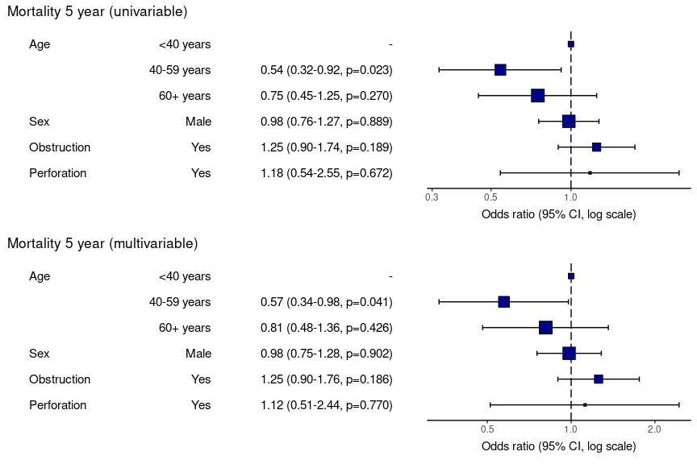

```r
library(finalfit)

explanatory = c("age.factor", "sex.factor", "obstruct.factor", "perfor.factor")
dependent = "mort_5yr"

fit_uni = colon_s %>%
    glmuni(dependent, explanatory)

p_uni = colon_s %>%
    or_plot(dependent, explanatory, suffix = " (univariable)", remove_ref = TRUE,
                    glmfit = fit_uni)
p_multi = colon_s %>%
    or_plot(dependent, explanatory, suffix = " (multivariable)", remove_ref = TRUE)

cowplot::plot_grid(p_uni, p_multi, ncol = 1)
```

### 1.06 Confidence interval type

Change the type of confidence interval. For GLM, this is “profile” by default, but confusingly “default” is also available (Wald) which is quicker but may be biased when the likelihood function is not symmetrical around the maximum likelihood estimate. Translated - best to use “profile” or an alternative approach (like bootstrapping) for final results.

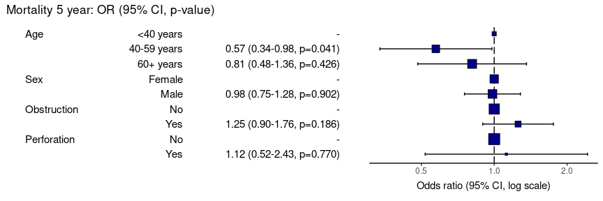

```r
library(finalfit)
explanatory = c("age.factor", "sex.factor", "obstruct.factor", "perfor.factor")
dependent = 'mort_5yr'
colon_s %>%
  or_plot(dependent, explanatory, confint_type = "default")
```

```r
# Note this example uses fig.height=3, fig.width=9
```

### 1.07 Remove reference levels

This will remove reference levels for binary variables.

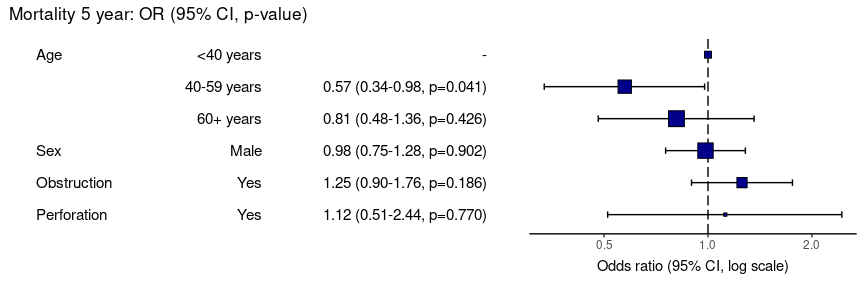

```r
library(finalfit)
explanatory = c("age.factor", "sex.factor", "obstruct.factor", "perfor.factor")
dependent = 'mort_5yr'
colon_s %>%
  or_plot(dependent, explanatory, remove_ref = TRUE)
```

```r
# Note this example uses fig.height=3, fig.width=9
```

### 1.08 Manually specifiy x-axis breaks

Note, this will not include labels that are outwith the axis range, i.e., if the axis starts at 0.2, adding 0.1 will not result in any change. Use `plot_opts` to alter axis range.

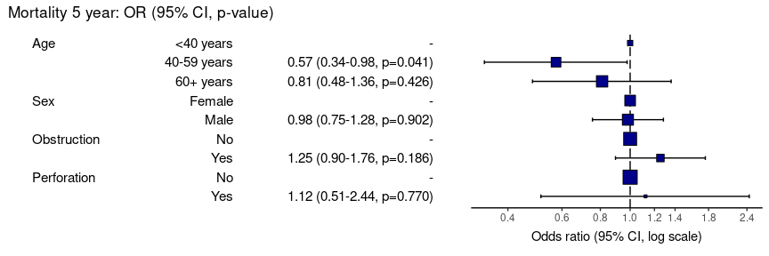

```r
library(finalfit)
explanatory = c("age.factor", "sex.factor", "obstruct.factor", "perfor.factor")
dependent = 'mort_5yr'
colon_s %>%
  or_plot(dependent, explanatory, breaks = c(0.4, 0.6, 0.8, 1.0, 1.2, 1.4, 1.8, 2.4))
```

```r
# Note this example uses fig.height=3, fig.width=9
```

### 1.09 Adjust table column spacing

Nudge *relative* column positions to manage white space. Use in combination with figure width to optimise.

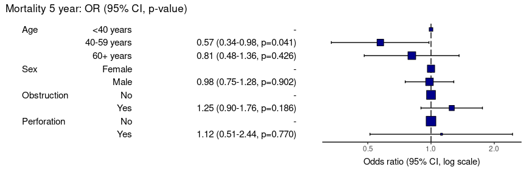

```r
library(finalfit)
explanatory = c("age.factor", "sex.factor", "obstruct.factor", "perfor.factor")
dependent = 'mort_5yr'
colon_s %>%
  or_plot(dependent, explanatory, column_space = c(-0.5, -0.1, 0.5))
```

```r
# Note this example uses fig.height=3, fig.width=9
```

### 1.10 Adjust or remove dependent variable label

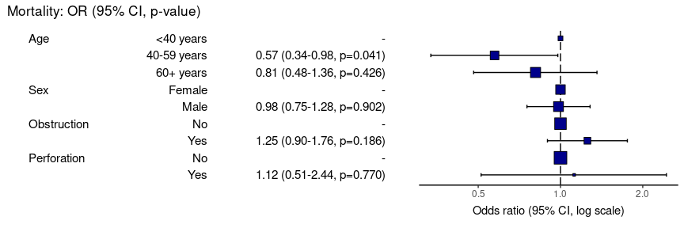

```r
library(finalfit)
explanatory = c("age.factor", "sex.factor", "obstruct.factor", "perfor.factor")
dependent = 'mort_5yr'
colon_s %>%
  or_plot(dependent, explanatory, dependent_label = "Mortality")
```

```r
# Note this example uses fig.height=3, fig.width=9
```

### 1.11 Add dependent variable label prefix

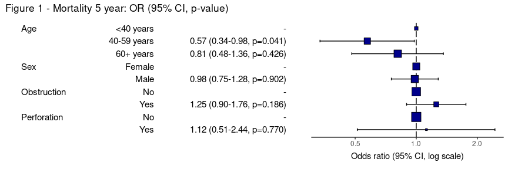

```r
library(finalfit)
explanatory = c("age.factor", "sex.factor", "obstruct.factor", "perfor.factor")
dependent = 'mort_5yr'
colon_s %>%
  or_plot(dependent, explanatory, prefix = "Figure 1 - ")
```

```r
# Note this example uses fig.height=3, fig.width=9
```

### 1.12 Adjust or remove dependent variable label suffix

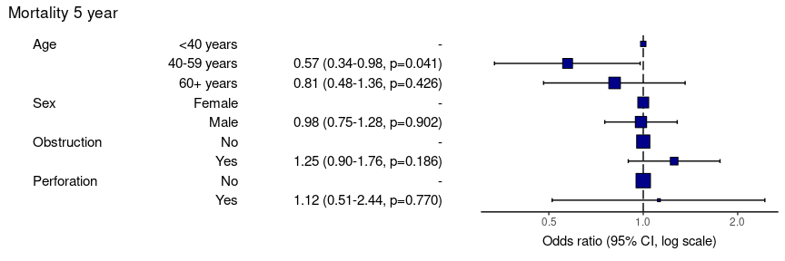

```r
library(finalfit)
explanatory = c("age.factor", "sex.factor", "obstruct.factor", "perfor.factor")
dependent = 'mort_5yr'
colon_s %>%
  or_plot(dependent, explanatory, suffix = "")
```

```r
# Note this example uses fig.height=3, fig.width=9
```